# Analysis Pipeline for the Paper Functionally Enigmatic Genes: Are We Still Looking Under the Lamppost for the Lost Keys?

Vy Tran

11/08/2019

Most codes were modifed from the [Weight Gene Correlation Network Analysis (WGCNA) tutorial] (https://horvath.genetics.ucla.edu/html/CoexpressionNetwork/Rpackages/WGCNA/) (Peter Langelder and Steve Horvath)

# 0. Load libraries and data:

Check working directory:

```r
getwd()
```

```
## [1] "D:/vytran/OneDrive - JHSPH/Functionally_enigmatic_genes"
```

Load required packages:

```r
if(!require("BiocManager", "plotrix")){
  install.packages("BiocManager")
}

BiocManager::install("WGCNA")
install.packages("tidyverse")
install.packages("plotrix")
library(tidyverse)
library(WGCNA)
library(plotrix)
```

Important setting:

```r
options(stringsAsFactors=FALSE)
```

Load RNA-seq data:

```r
load(file = "Data Inputs/PRAD.Rdata") #Loaded as PRAD_DATA
load(file = "Data Inputs/COAD.Rdata") #Loaded as COAD_DATA
load(file = "Data Inputs/GBMLGG.Rdata") #Loaded as GBMLGG_DATA
```

Load PubMed publications, unfavorable genes, and disease index data:

```r
load(file = "Data Inputs/PubMed_ID_for_all_TCGA_genes.Rdata") #Loaded as PubMed
load(file = "Data Inputs/Prognostic_unfavorable_genes.Rdata") #Loaded as unfavorable_genes
load(file = "Data Inputs/Gleasonscore_PRAD.Rdata") #Loaded as Gleason
load(file = "Data Inputs/Aggressiveness score_COAD.Rdata") #Loaded as COAD.aggressiveness
load(file = "Data Inputs/Cindex_GBMLGG.Rdata") #Loaded aS GBMLGG.Cindex
```

# 1. Create Figure 1 for PubMed distribution of prognostic unfavorable genes

Create a data frame including both Pubmed publications and prognostic unfavorable genes:

```r
colnames(unfavorable_genes) = c("genename")
Pubmed_unfavorable = merge(unfavorable_genes, PubMed, by = "genename")
colnames(Pubmed_unfavorable)
```

```
## [1] "genename" "entrez"   "PubMed"
```

Plot Figure 1:

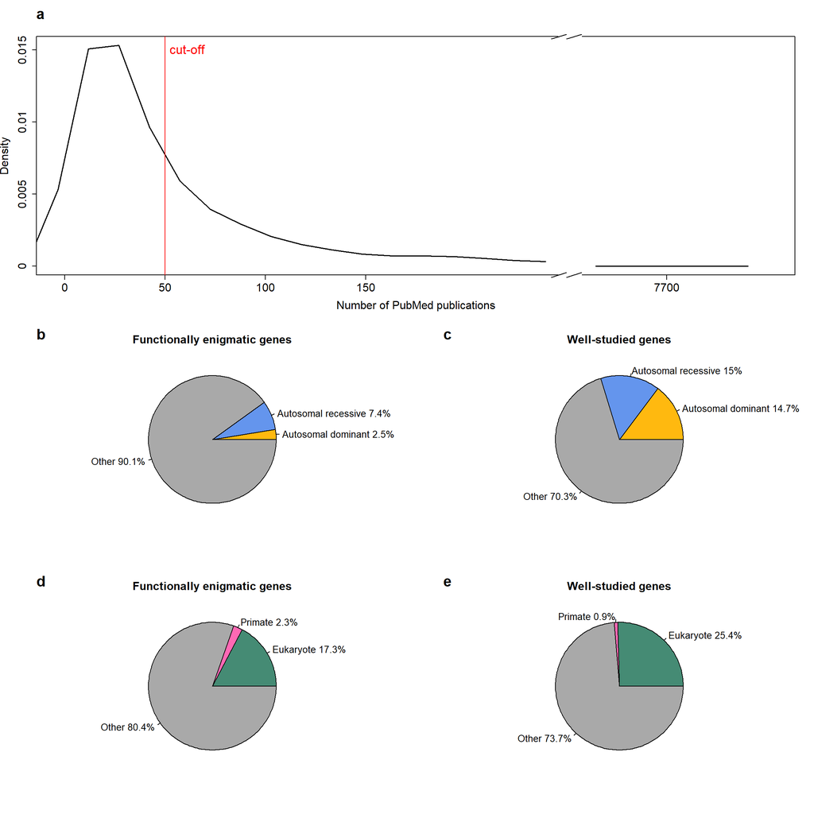

```r
layout(matrix(c(1,1,2,3,4,5), 3, 2, byrow = TRUE),
       widths=c(1.5,1.5), heights=c(1.3,1,1))

par(cex.axis = 1.5)
density_unfavorable = density(Pubmed_unfavorable$PubMed)
gap.plot(x = density_unfavorable$x, y = density_unfavorable$y, gap = c(250, 7650), gap.axis = "x", type = "l", xlim = c(0, 7750),
         ylab = "Density", xlab = "Number of PubMed publications", lwd = 1.9, cex.lab = 1.5,
         xtics = c(0, 50, 100, 150, 300, 6500, 7700))
axis.break(1, 250, breakcol="white", style="gap") #to cover the lines created by the gap.plot fucntion
axis.break(axis = 1, 250, style = "slash") #to add a pair of slash markers on the x axis
axis.break(axis = 3, 250, style = "slash")
abline(v = 50, col = "red")
text(x = 50, y = 0.015,"cut-off",pos=4, col = "red", cex = 1.7)
title(main ="a", adj=0, line=2, font=2, cex.main = 2)

par(cex.axis = 1)
slices_enigmatic_autosomal = c(2.5, 7.4, 90.1)
lbls = c("Autosomal dominant", "Autosomal recessive", "Other")
lbls = paste(lbls, slices_enigmatic_autosomal) # add percents to labels
lbls = paste(lbls,"%",sep="") # add % to labels
pie(slices_enigmatic_autosomal, radius = 0.84, labels = lbls, cex = 1.3, main = "Functionally enigmatic genes",
    cex.main = 1.5, col = c("darkgoldenrod1", "cornflowerblue", "darkgray"))
title(main ="b", adj=0, line=2, font=2, cex.main = 2)

slices_wellstudied_autosomal = c(14.7,15.0, 70.3)
lbls = c("Autosomal dominant", "Autosomal recessive", "Other")
lbls = paste(lbls, slices_wellstudied_autosomal) # add percents to labels
lbls = paste(lbls,"%",sep="") # add % to labels
pie(slices_wellstudied_autosomal, radius = 0.84,labels = lbls, cex = 1.3, cex.main = 1.5, main="Well-studied genes", col = c("darkgoldenrod1", "cornflowerblue", "darkgray"))
title(main ="c", adj=0, line=2, font=2, cex.main = 2)

slices_enigmatic_species = c(753,102, 3507)
lbls = c("Eukaryote", "Primate", "Other")
pct = round(slices_enigmatic_species/sum(slices_enigmatic_species)*100, digits = 1)
lbls = paste(lbls, pct) # add percents to labels
lbls = paste(lbls,"%",sep="") # add % to labels
pie(slices_enigmatic_species, radius = 0.84, labels = lbls, cex = 1.3, cex.main = 1.5, main = "Functionally enigmatic genes", col = c( "aquamarine4", "hotpink", "darkgray"))
title(main ="d", adj=0, line=2, font=2, cex.main = 2)

slices_wellstudied_species = c(555,19,1607)
lbls = c("Eukaryote", "Primate", "Other")
pct = round(slices_wellstudied_species/sum(slices_wellstudied_species)*100, digits = 1)
lbls = paste(lbls, pct) # add percents to labels
lbls = paste(lbls,"%",sep="") # add % to labels
pie(slices_wellstudied_species, radius = 0.84, cex = 1.3, cex.main = 1.5, main="Well-studied genes", labels = lbls, col = c("aquamarine4","hotpink", "darkgray"))
title(main ="e", adj=0, line=2, font=2, cex.main = 2)
```

# 2. WGCNA Analysis for prostate adenocarcinoma (PRAD) data set

## 2a. Data pre-processing

Remove uninformative data:

```r
PRAD = PRAD_DATA
row.names(PRAD) = PRAD_DATA[,1]; colnames(PRAD) = PRAD_DATA[1,]
PRAD = PRAD[-c(1,2),-1]
```

Convert data frame to numeric matrix:

```r
PRAD1 = as.matrix(sapply(PRAD, as.numeric))
colnames(PRAD1) = colnames(PRAD)
row.names(PRAD1) = row.names(PRAD)
class(PRAD1)
```

```
## [1] "matrix"
```

```r
is.numeric(PRAD1)
```

```
## [1] TRUE
```

Transpose matrix and filter for 10,000 most variant genes:

```r
PRADdata = t(PRAD1[order(apply(PRAD1,1,mad), decreasing = T)[1:10000],])
```

Check if PRADdata has many missing values:

```r
gsg = goodSamplesGenes(PRADdata, verbose = 3)
```

```
##  Flagging genes and samples with too many missing values...
##   ..step 1
```

```r
gsg$allOK
```

```
## [1] TRUE
```

The command returned “TRUE”, so all genes have passed the cuts.

Re-cluster the samples (in contrast to clustering genes that will come later) to see if there are any obvious outliers:

```r
sampleTree = hclust(dist(PRADdata), method = "average")
```

Plot the sample tree:

```r
sizeGrWindow(12,9)
par(cex = 0.6);
par(mar = c(0,4,2,0))
plot(sampleTree, main = "Sample clustering to detect outliers for PRAD", sub="", xlab="", cex.lab = 1.5,
     cex.axis = 1.5, cex.main = 2)
```

It appears there is no obvious outlier. The variable PRADdata now contains the expression data ready for WGCNA analysis.

## 2b. Network analysis with WGCNA

Constructing a weighted gene network entails the choice of the soft thresholding power β to which co-expression similarity is raised to calculate adjacency. The choice of the soft thresholding power is based on the criterion of approximate scale-free topology.

Choose a set of soft-thresholding powers and Call the network topology analysis function:

```r
powers = c(c(1:10), seq(from = 12, to=20, by=2))
sft = pickSoftThreshold(PRADdata, powerVector = powers, verbose = 5)
```

Plot the results:

```r
sizeGrWindow(9, 5)
par(mfrow = c(1,2));
cex1 = 0.9;
# Scale-free topology fit index as a function of the soft-thresholding power
plot(sft$fitIndices[,1], -sign(sft$fitIndices[,3])*sft$fitIndices[,2],
     xlab="Soft Threshold (power)",ylab="Scale Free Topology Model Fit,signed R^2",type="n",
     main = paste("Scale independence"));
text(sft$fitIndices[,1], -sign(sft$fitIndices[,3])*sft$fitIndices[,2],
     labels=powers,cex=cex1,col="red");
# this line corresponds to using an R^2 cut-off of h
abline(h=0.90,col="red")
# Mean connectivity as a function of the soft-thresholding power
plot(sft$fitIndices[,1], sft$fitIndices[,5],
     xlab="Soft Threshold (power)",ylab="Mean Connectivity", type="n",
     main = paste("Mean connectivity"))
text(sft$fitIndices[,1], sft$fitIndices[,5], labels=powers, cex=cex1,col="red")
```

Based on the scale-free topology graph, the soft-thresholding power of 6 was chosen.

Constructing the gene network and identifying modules for PRAD:

```r
net_PRAD = blockwiseModules(PRADdata, power = 6,
                            TOMType = "unsigned", minModuleSize = 30,
                            reassignThreshold = 0, mergeCutHeight = 0.25,
                            numericLabels = TRUE, pamRespectsDendro = FALSE,
                            saveTOMs = TRUE,
                            saveTOMFileBase = "PRADTOM",
                            verbose = 3)
```

To see how many modules were identified and what the module sizes are, one can use table(net$colors):

```r
table(net_PRAD$colors)
```

```
##
##    0    1    2    3    4    5    6    7    8    9   10   11   12   13   14
## 1739 3163 1451  974  823  336  285  269  234  137  127  103   90   72   60
##   15   16   17
##   57   40   40
```

Now we can visualize the modules:

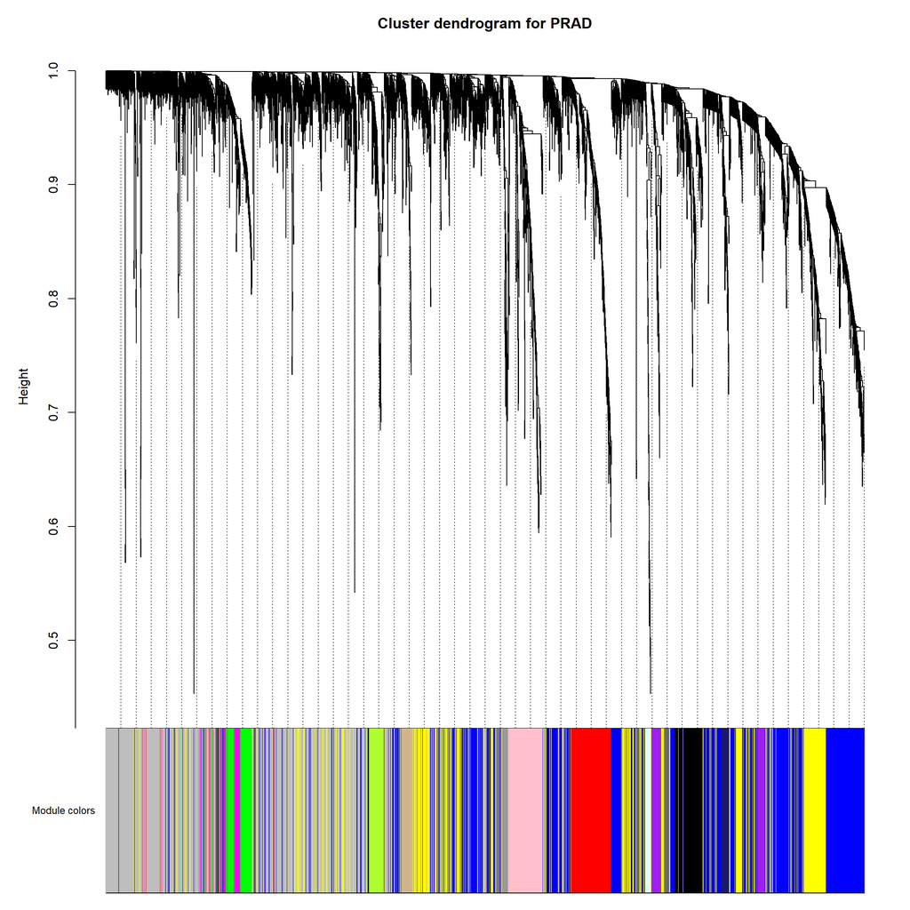

```r
#Convert labels to colors for plotting
mergedColors_PRAD = labels2colors(net_PRAD$colors)

#Plot the dendrogram and the module colors underneath
par(mfrow = c(1,1))
plotDendroAndColors(net_PRAD$dendrograms[[1]], mergedColors_PRAD[net_PRAD$blockGenes[[1]]],
                    "Module colors",
                    dendroLabels = FALSE, hang = 0.03,
                    addGuide = TRUE, guideHang = 0.05, main = "Cluster dendrogram for PRAD")
```

We now save the module assignment and module eigengene information necessary for subsequent analysis:

```r
moduleLabels_PRAD = net_PRAD$colors
moduleColors_PRAD = labels2colors(net_PRAD$colors)
MEs_PRAD = net_PRAD$MEs
geneTree_PRAD = net_PRAD$dendrograms[[1]]
save(MEs_PRAD, moduleLabels_PRAD, moduleColors_PRAD, geneTree_PRAD,
     file = "Data Outputs/PRADnetwork_modulecolor_and_label.RData")
```

Create a data frame holding the following information for all genes: gene names, module color, module membership, and p-values in all modules:

```r
#Define numbers of genes and samples
nGenes = ncol(PRADdata)
nSamples = nrow(PRADdata)

#Recalculate MEs with color labels
MEs0_PRAD = moduleEigengenes(PRADdata, moduleColors_PRAD)$eigengenes
MEs_PRAD = orderMEs(MEs0_PRAD)
```

Calculate module membership to identify important genes. Module membership is defined as the correlation of the module eigengene with gene expression profile of the gene.

```r
#Get the names (colors) of the modules
modNames_PRAD = substring(names(MEs_PRAD), 3)
geneModuleMembership_PRAD = as.data.frame(cor(PRADdata, MEs_PRAD, use = "p"))
MMPvalue_PRAD = as.data.frame(corPvalueStudent(as.matrix(geneModuleMembership_PRAD), nSamples))
names(geneModuleMembership_PRAD) = paste("MM", modNames_PRAD, sep="")
names(MMPvalue_PRAD) = paste("p.MM", modNames_PRAD, sep="")
```

Create the starting data frame:

```r
geneInfoPRAD = data.frame(Genename = colnames(PRADdata),
                          moduleColor = moduleColors_PRAD,
                          geneModuleMembership_PRAD,
                          MMPvalue_PRAD)
```

Order the genes in the geneInfo variable by module color:

```r
geneOrder_PRAD = order(geneInfoPRAD$moduleColor)
geneInfoPRAD_1 = geneInfoPRAD[geneOrder_PRAD, ]
```

Save the data frame:

```r
save(geneInfoPRAD_1, file = "Data Outputs/PRAD_geneMM.Rdata")
```

Now we calculate scaled connectivity of genes in the PRAD network:

Create a TOM matrix:

```r
tom_PRAD = TOMsimilarityFromExpr(PRADdata)
```

```
## TOM calculation: adjacency..
## ..will not use multithreading.
##  Fraction of slow calculations: 0.000000
## ..connectivity..
## ..matrix multiplication (system BLAS)..
## ..normalization..
## ..done.
```

```r
fun = fundamentalNetworkConcepts(tom_PRAD, GS = NULL) #May take > 30 minutes to compute
```

We want the scaled connectivity k = connectivity/max(connectivity), which is an indication of hub gene significance.

```r
connectivity_PRAD = as.data.frame(fun$ScaledConnectivity)
row.names(connectivity_PRAD) = colnames(PRADdata)
```

Next step is to merge the gene significance data frame with TCGA PubMed ID data. First, we separate the row name into two columns (official gene symbol and Entrez ID) before merging with PubMed info:

```r
#Turn make the rowname column into a new column
connectivity_PRAD = tibble::rownames_to_column(connectivity_PRAD, "gene")
connectivity_PRAD = separate(connectivity_PRAD, 1, into = c("genename", "entrez"), sep = "([|])", remove = FALSE)

#Separate the "gene" column
row.names(connectivity_PRAD) = connectivity_PRAD$gene
connectivity_PRAD = connectivity_PRAD[,-1]

#Merge genesig_PRAD and PubMed
connectivity_PubMed_PRAD = merge(PubMed, connectivity_PRAD, by = "entrez")
connectivity_PubMed_PRAD = connectivity_PubMed_PRAD[, -4]
colnames(connectivity_PubMed_PRAD) = c("entrez", "genename", "PubMed", "scaledconnectivity")
```

Save the data:

```r
save(connectivity_PubMed_PRAD, file = "Data Outputs/Scaled connectivity and PubMed ID for PRAD.Rdata")
```

We also combine scaled connectivity with Gleason score, a metric for prostate cancer severity:

```r
colnames(Gleason) = c("genename", "entrez", "Q", "GleasonScore")
```

Add Gleason score to connectivity_PubMed_PRAD dataframe:

```r
Gleason_connectivity_PubMed_PRAD = merge(connectivity_PubMed_PRAD, Gleason, by = "entrez")
Gleason_connectivity_PubMed_PRAD = Gleason_connectivity_PubMed_PRAD[, -c(2)]
dim(Gleason_connectivity_PubMed_PRAD)
```

```
## [1] 3351    6
```

```r
class(Gleason_connectivity_PubMed_PRAD)
```

```
## [1] "data.frame"
```

```r
colnames(Gleason_connectivity_PubMed_PRAD)[colnames(Gleason_connectivity_PubMed_PRAD) == "genename.y"] = "gemename"
```

Save the data:

```r
save(Gleason_connectivity_PubMed_PRAD, file = "Data Outputs/Scaled connectivity, PubMed number, and Gleason score for PRAD.RData")
```